# Movie rating predictor - Using Linear Regression

Santhosh Thirumalai

June 13, 2019

# INTRODUCTION

The GOAL for this algorithm is to Recommend a movie based on predicting the rating using a training dataset called “edx” and test dataset called “Validation” which is scrapped from movielens dataset. The script uses a linear model (explained below) to predict the outcomes.

The Success of the algorithm will be measured based on the Root Mean Square Value (RMSE). That is to acheive an RMSE < 1 and most preferred RMSE would be < 0.87750.

This Linear model will use the average ratings for the movies and add different biases based on various predictors as given below

Y_hat = mu + b_i + b_u + b_g + b_t  
mu = Average rating of all movies  
b_i = Bias based on Movies  
b_u = Bias based on Users  
b_g = Bias based on Genres  
b_t = Bias based on Date the movie is rated

The code is present in the following repository

- [Github] (https://github.com/sthirumalai2020/EDX-HARVARDX.git)

# MODEL DETAILS

The below steps illustrates computation of biases based on the predictors Movies, Users who rated the movies, Genres and Date when the movie was rated.

As a first step calculate the mean for the ratings for all the movies using the R code given below

```r
mu<-mean(edx$rating)
```

1.Compute the BIAS based on movies

The graph is plotted by using the average of ratings for the movies with rating count 20000 or more.

This will prove the BIAS based on the movies and it’s ratings.

Not all movies are rated the same.

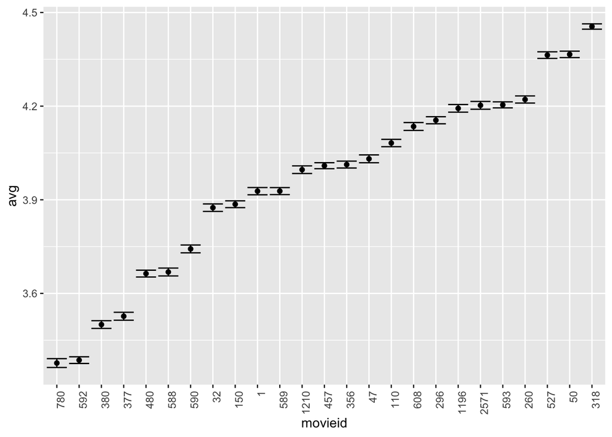

The code below will create the model based on movie BIAS

```r
#=======================================================================#
# Compute the BIAS b_i based on the movies
#=======================================================================#
movie_avg<-edx %>% group_by(movieId) %>% summarize(b_i = mean(rating-mu))

#=======================================================================#
# Improve the predicted value mu by adding the BIAS based on the movies
#=======================================================================#
pred_with_movie_bias <- validation %>% left_join(movie_avg, by='movieId') %>% .$b_i

pred_with_movie_bias <- pred_with_movie_bias + mu
```

2. Compute the BIAS based on users who rated the movies.

The graph below is plotted by using the average of ratings for the movies rated by different users with rating count 2000 or more rated by individual users.

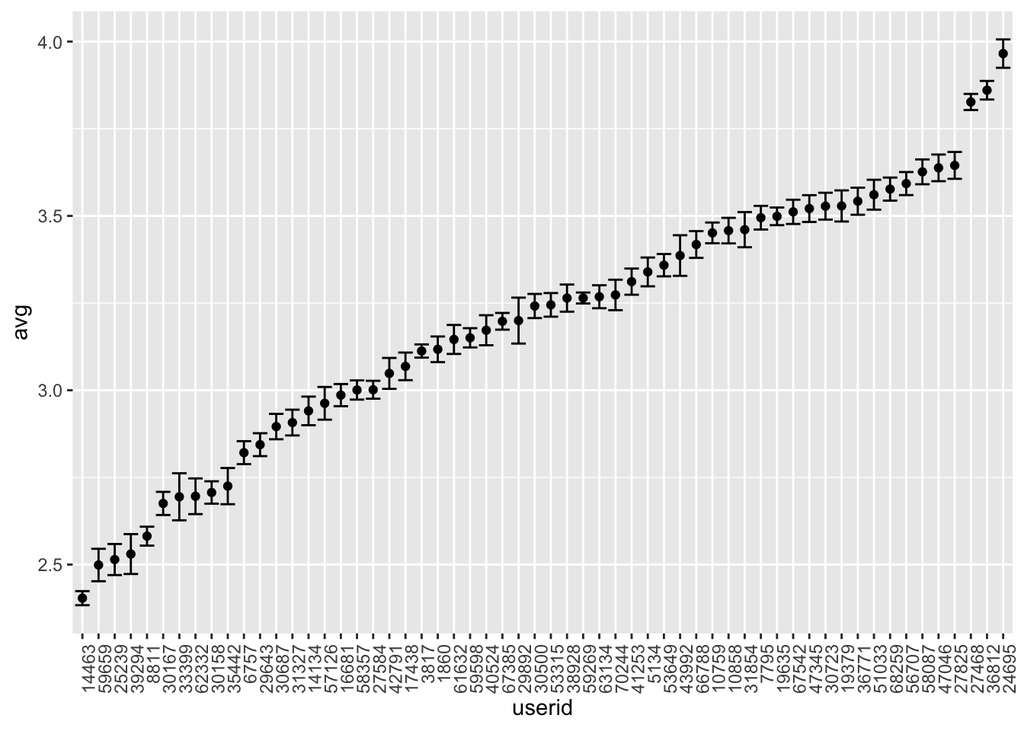

The code below will create the model based on Movie BIAS & User Bias

```r
#=======================================================================#
# Compute BIAS b_u on users rated the movies
#=======================================================================#

user_avgs<-edx %>% left_join(movie_avg,by="movieId") %>%
  group_by(userId) %>%
  summarize(b_u = mean(rating - mu - b_i))
#=======================================================================#
# Improve the predicted value mu by adding the BIAS
# based on the movies and BIAS based on users
#=======================================================================#
pred_with_user_bias <- validation %>% left_join(movie_avg, by='movieId') %>%
  left_join(user_avgs,by='userId') %>% mutate(pred = mu + b_i + b_u) %>% .$pred
```

3. Compute the BIAS based on Genres of the Movies rated.

The graph below is plotted by using the average of ratings for the movies by different genres with rating count 50000.

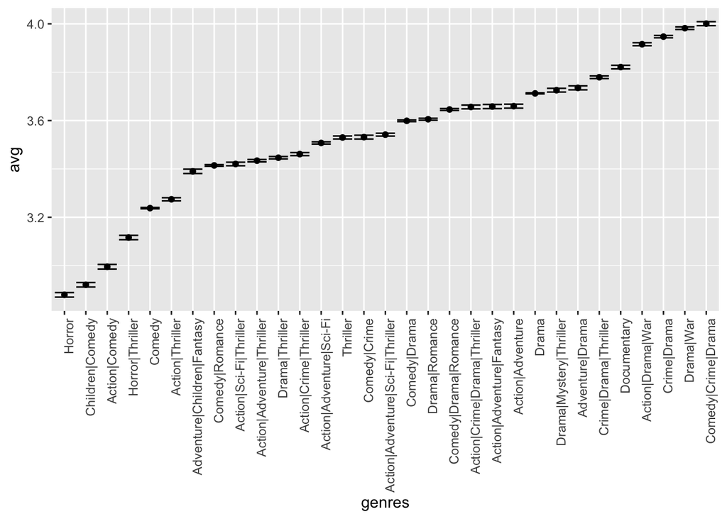

The code below will create the model based on Movie BIAS,User BIAS and Genre BIAS

```r
#=======================================================================#
# Compute BIAS b_g on genres of the movies
#=======================================================================#

genre_avgs<-edx %>% left_join(movie_avg,by="movieId") %>%
  left_join(user_avgs,by="userId")%>%group_by(genres) %>%
  summarize(b_g = mean(rating - mu - b_i - b_u))

#=======================================================================#
# Improve the predicted value mu by adding the
# BIAS based on the movies/users/Genres
#=======================================================================#
pred_with_genre_bias <- validation %>% left_join(movie_avg, by='movieId') %>%
  left_join(user_avgs,by='userId') %>% left_join(genre_avgs, by='genres') %>%
  mutate(pred_genre = mu + b_i + b_u + b_g) %>% .$pred_genre
```

4. Compute the BIAS based on Date when the Movies are rated.

The graph below is plotted by using the average of ratings for the movies rated on particular days where the rating coun on that day is 10000 or more.

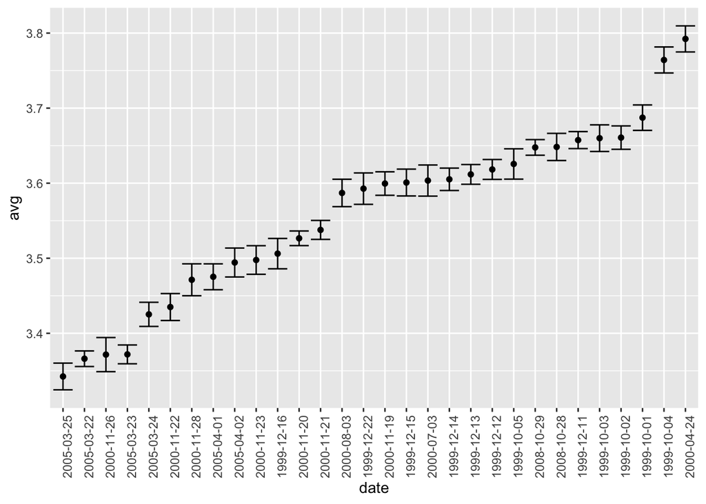

The code below will create the model based on Movie BIAS,User BIAS, Genre BIAS and DATE BIAS

```r
#=======================================================================#
# Compute BIAS b_t on time_stamp of the ratings
#=======================================================================#

ts_avgs<-edx_new %>% left_join(movie_avg,by="movieId") %>%
  left_join(user_avgs,by="userId")%>% left_join(genre_avgs,by="genres") %>%
  group_by(date) %>%
  summarize(b_t = mean(rating - mu - b_i - b_u - b_g))

#=======================================================================#
# Improve the predicted value mu by adding the
# BIAS based on the movies/users/Genres/Date
#=======================================================================#
pred_with_date_bias <- validation_new %>% left_join(movie_avg, by='movieId') %>%
  left_join(user_avgs,by='userId') %>% left_join(genre_avgs, by='genres') %>%
  left_join(ts_avgs, by='date') %>%
  mutate(pred_date = mu + b_i + b_u + b_g + b_t) %>% .$pred_date
```

# RESULTS

The below table will display the RMSE computed for each model.

| method | RMSE |
| --- | --- |
| RMSE for Average Rating | 1.0612018 |
| RMSE with Movie BIAS | 0.9439087 |
| RMSE after USER BIAS | 0.8653488 |
| RMSE after GENRE BIAS | 0.8649469 |
| RMSE after Date BIAS | 0.8644285 |

# CONCLUSION

The bar chart below will prove that adding the BIASes to the model significantly reduces the squared errors and improved the prediction.

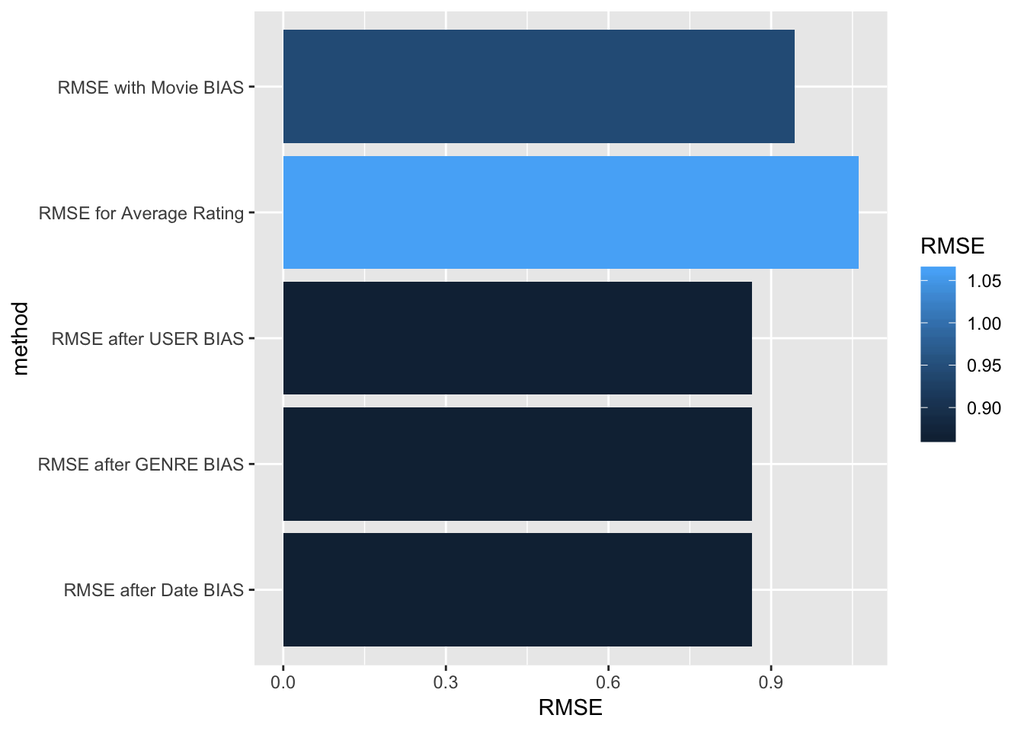